# ggplot2

## Goals

- An introduction to the *Grammar of Graphics*
- An introduction to *ggplot*

## ggplot2

- ggplot2 is an R package for visualizing data.
- It is part of the [tidyverse](https://ggplot2.tidyverse.org/)
- It is based on a concept called [The Grammar of Graphics](https://link.springer.com/content/pdf/10.1007%2F978-3-642-21551-3_13.pdf) by Leland Wilkinson
- It has been programmed and implemented as an R package by [Hadley Wickham](http://hadley.nz/).
- There is a [book available on ggplot2](https://link.springer.com/book/10.1007/978-3-319-24277-4)
- Which you find [at https://ggplot2-book.org/](https://ggplot2-book.org/) as an online book.

## ggplot components

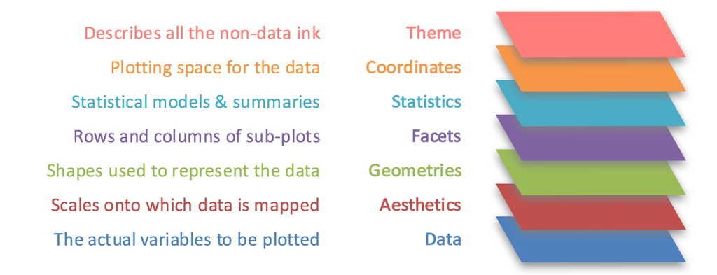

## Basic concepts of ggplot2

A ggplot graphic has at least three key components:

1. *data*
2. A set of *aesthetic mappings* between variables in the data and visual properties (x and y axis, colour, dotsize etc.)
3. At least one *geometries layer* which describes how to render each observation (lines, point, bars etc.). Layers are usually created with a **geom** function

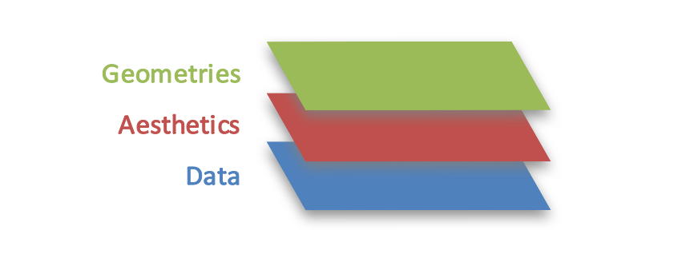

## Task

- Copy and execute these lines:
- `displ` displacement by `hwy` highway miles per gallon

```r
library(tidyverse)
ggplot(data = mpg, mapping = aes(x = displ, y = hwy)) +
  geom_point()
```

**Please stop the video here! Continue after completing the task!**

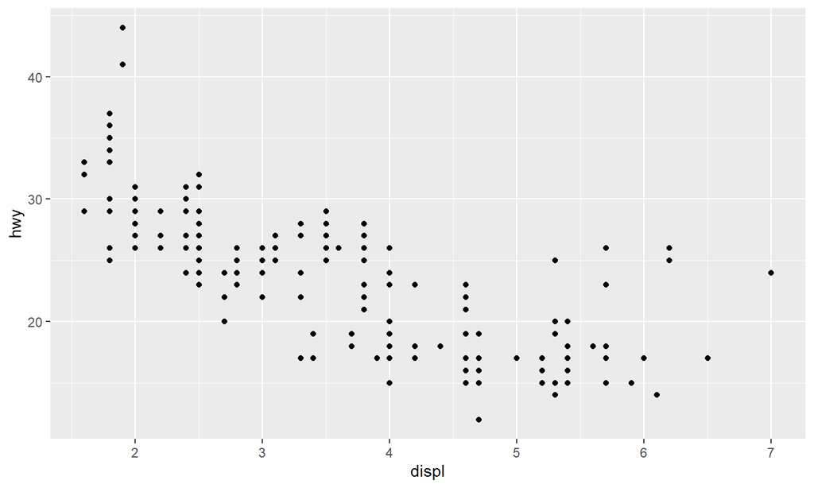

```r
library(tidyverse)
ggplot(mpg, aes(x = displ, y = hwy)) +
  geom_point()
```

## Task

- Copy and execute these lines:
- Axis: `displ` displacement and `hwy` highway miles per gallon
- Colour: `drv` f = front-wheel drive, r = rear wheel drive, 4 = 4wd
- Size: `cyl` number of cylinders

```r
ggplot(mpg, aes(x = displ, y = hwy, color = drv, size = cyl)) +
  geom_point()
```

**Please stop the video here! Continue after completing the task!**

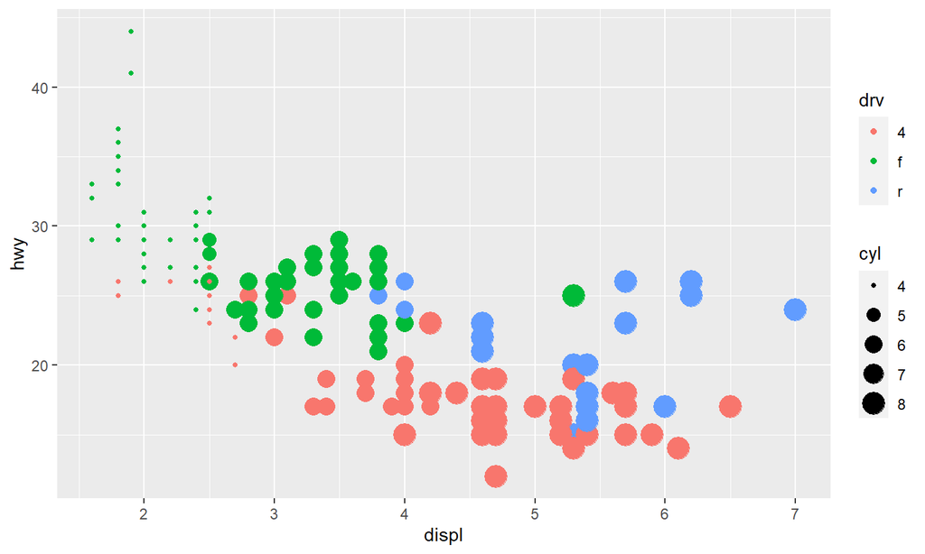

```r
ggplot(mpg, aes(x = displ, y = hwy, color = drv, size = cyl)) +
  geom_point()
```

## The `ggplot()` function

The main function is `ggplot()`. It takes two arguments:

1. `data` : A *data frame*
2. `mapping` : **Aesthetic mappings** provided with the `aes()` function.

Additional layers are added with a `+` sign.

```r
ggplot(mpg, aes(x = displ, y = hwy, color = drv, size = cyl)) +
  geom_point()
```

## Task

- Take the `mpg` data frame.
- Plot a graph with …
  - `cty` and `hwy` displayed on the axis and
  - the colour is mapped on the variable `class` and
  - the shape (`shape = drv`) is mapped on the variable `drv`.
- Use the `geom_point()` layer.

**Please stop the video here! Continue after completing the task!**

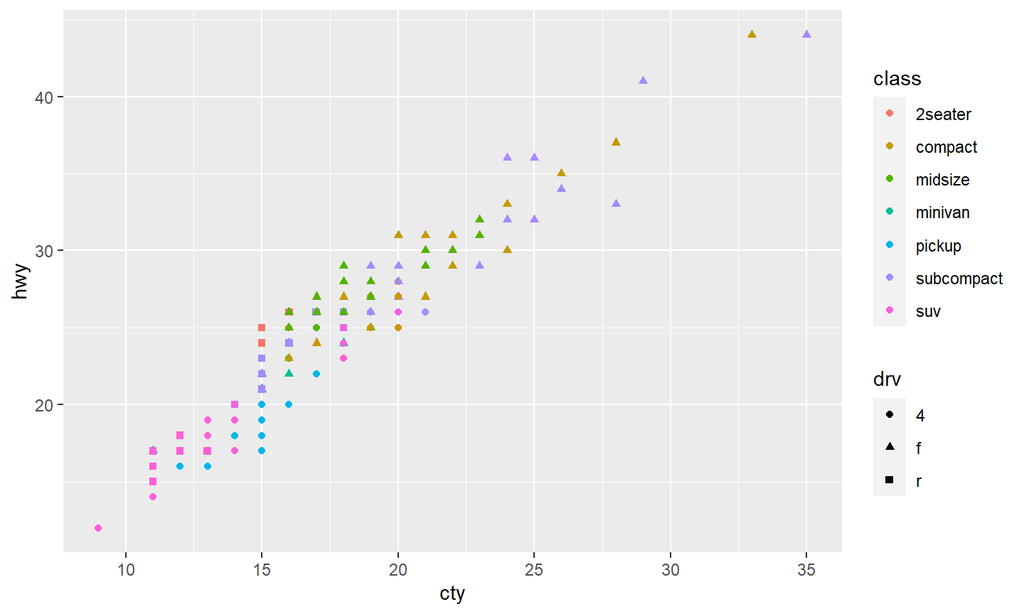

```r
ggplot(mpg, aes(cty, hwy, colour = class, shape = drv))  +
  geom_point()
```

## Fixed aestetics

- *Aestetics* can also be provided in the `geom` function.
- Here they are not mapped to variables but fixed.

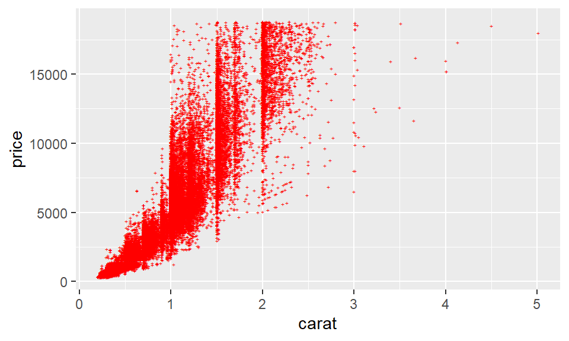

```r
ggplot(diamonds, aes(carat, price)) +
  geom_point(colour ="red", shape = "+", size = 1)
```

## Some geoms

- `geom_point()` : Dots for each data point.
- `geom_line()` : Lines connecting each x-axis data point
- `geom_bar()` : Bars
- `geom_text()` : Text at x and y positions
- `geom_smooth()` : Smoothed conditional means

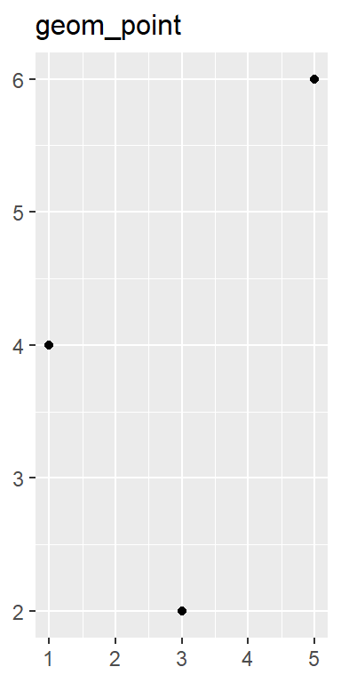

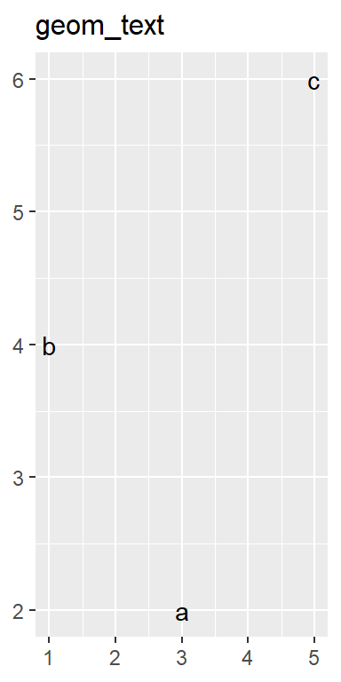

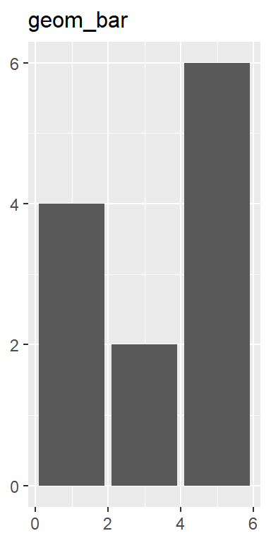

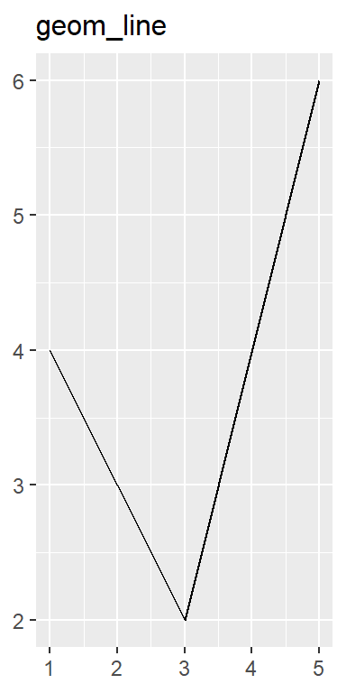

## Task

- Take the `economics` data frame
- Create a lineplot for `date` and `unemployment`. (`geom_line()`)
- Add a second layer for red dots of size = 1 (`geom_point()`)

**Please stop the video here! Continue after completing the task!**

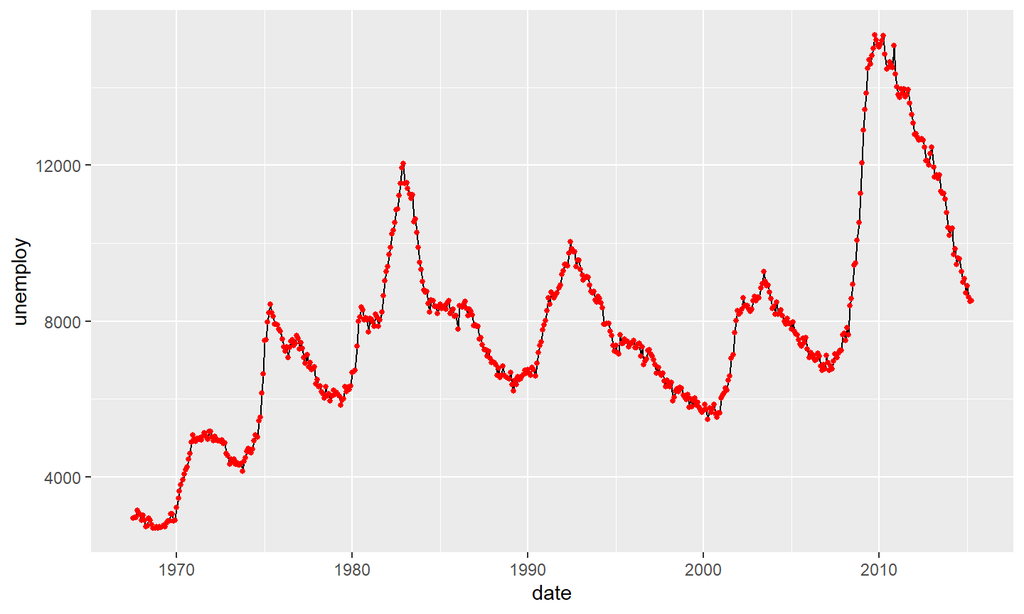

```r
ggplot(economics, aes(date, unemploy)) +
  geom_line() +
  geom_point(color = "red", size = 1)
```

## `geom_bar()`

- `geom_bar()` draws bars
- By default, it counts the numbers of entities of categories provided as the `x` variable

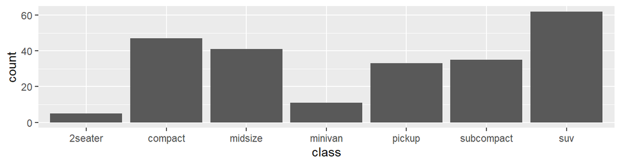

```r
# Number of cars in each class:
ggplot(mpg, aes(class)) +
  geom_bar()
```

## Task

- Take the `mpg` data frame.
- Create a barplot with the counts of categories for the `drv` variable.
- Colour the bars `red` with the `fill` argument.
- Set the argument `width = 0.8` to resize the bar width.

**Please stop the video here! Continue after completing the task!**

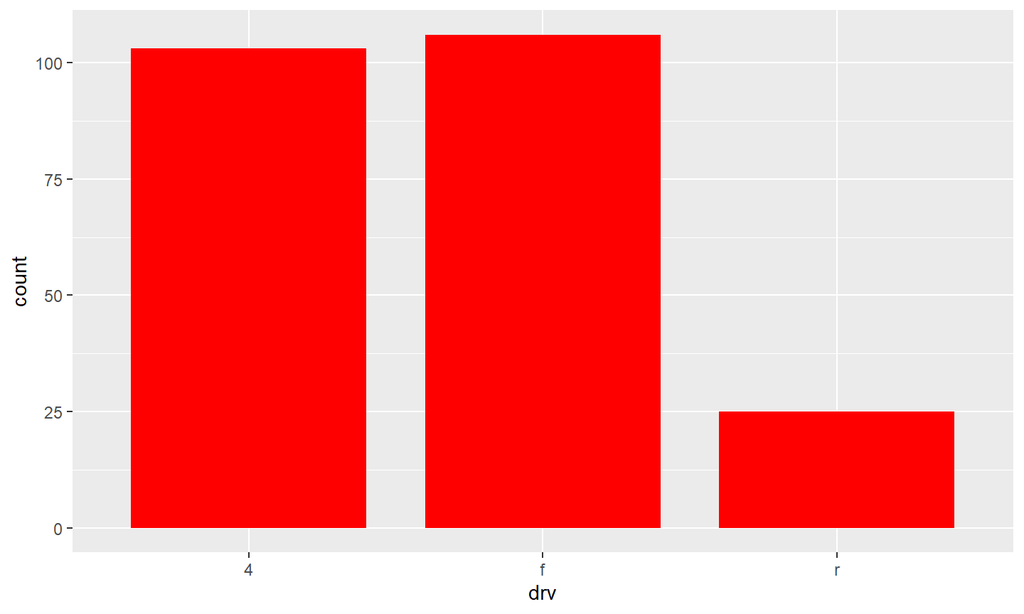

```r
ggplot(mpg, aes(drv)) +
  geom_bar(fill = "red", width = 0.8)
```

## `geom_bar()`

- With the argument `stat = "identity"`, bar heights and bar categories are taken from the x and y variables:

## Example

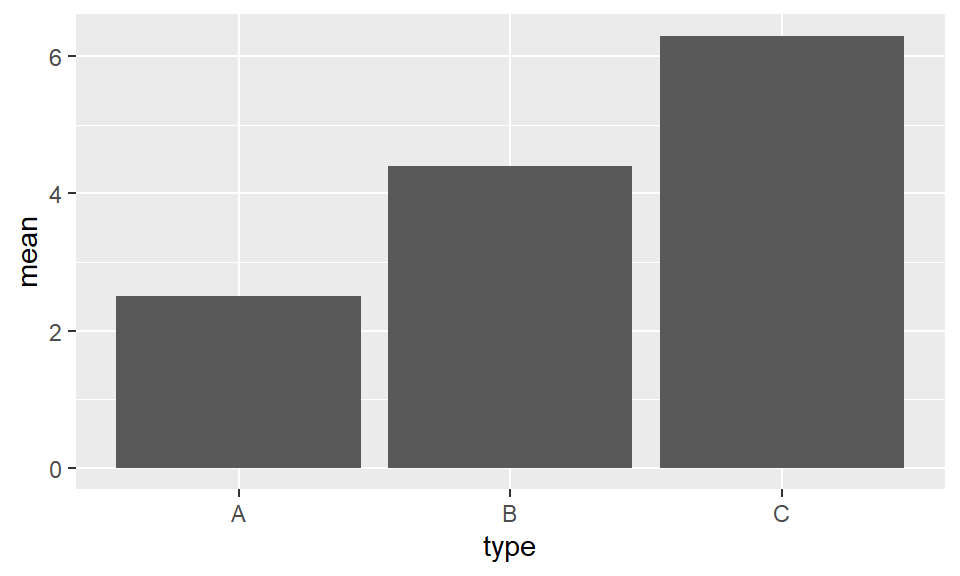

```r
df <- data.frame(
  type = c("A", "B", "C"),
  mean = c(2.5, 4.4, 6.3)
)
ggplot(df, aes(x = type, y = mean)) +
  geom_bar(stat = "identity")
```

## Task

- Take the `starwars` database.
- Calculate the bmi. (`mutate(bmi = mass / (height / 100)^2)`)
- Summar ise the median of the bmi grouped by species. (`summarise(mean_bmi = median(bmi, na.rm = TRUE)`)
- Create a fitting barplot.

**Please stop the video here! Continue after completing the task!**

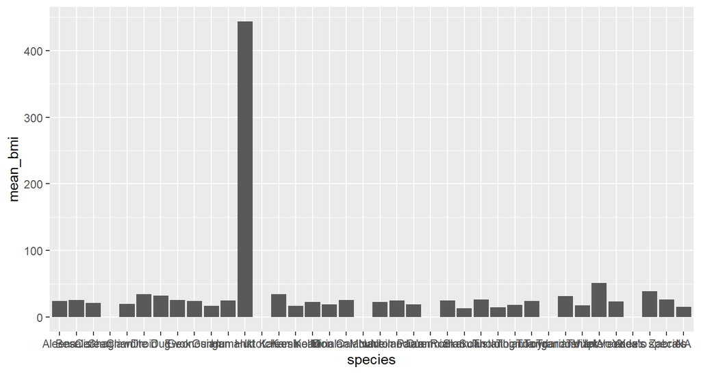

```r
starwars %>%
  mutate(bmi = mass / (height / 100)^2) %>%
  group_by(species) %>%
  summarise(
    mean_bmi = median(bmi, na.rm = TRUE)
  ) %>%
  ggplot(aes(species, mean_bmi)) +
    geom_bar(stat = "identity")
```

## `geom_smooth()`

geom_smooth() is used to add smoothed conditional means in scatterplots.

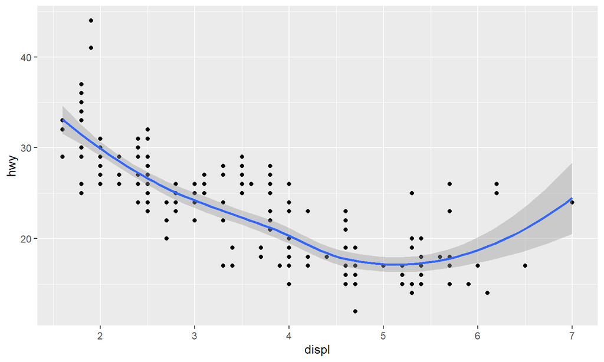

```r
ggplot(mpg,aes(displ, hwy)) +
  geom_point() +
  geom_smooth()
```

## Task

- Take the `economics` data frame.
- Create a scatterplot with number of unemployed `unemploy` by population `pop`.
- Add a `geom_smooth` layer.

**Please stop the video here! Continue after completing the task!**

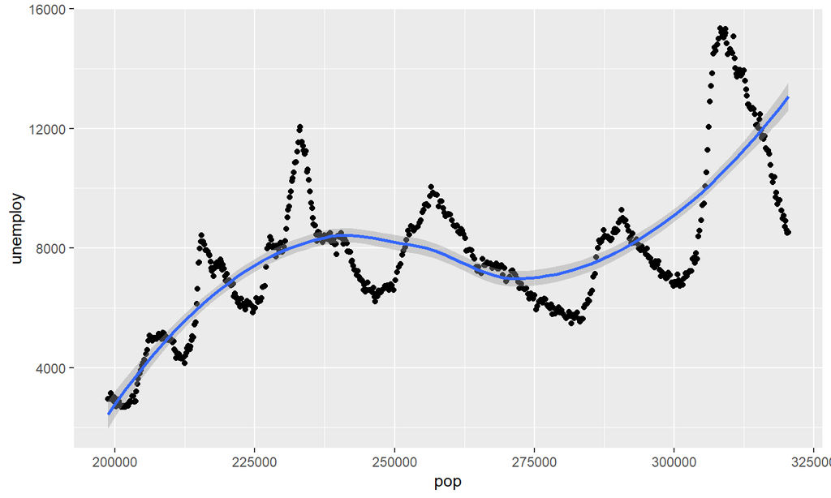

```r
economics %>%
  ggplot(aes(pop, unemploy)) +
    geom_point() +
    geom_smooth()
```

## Task

- Install and activate the library `dslabs`.
- Take the dataframe `gapminder`.
- Group the data by `year` and `continent`. (`group_by(year, continent)`)
- Use the `summarize()` function to calculate the mean of `infant_mortality`.
- Create a line and dot plot with `year` on x-axis, mean of `infant_mortality` on y-axis, and `continent` as line/dot colours.
- Add a `smooth` layer.

**Please stop the video here! Continue after completing the task!**

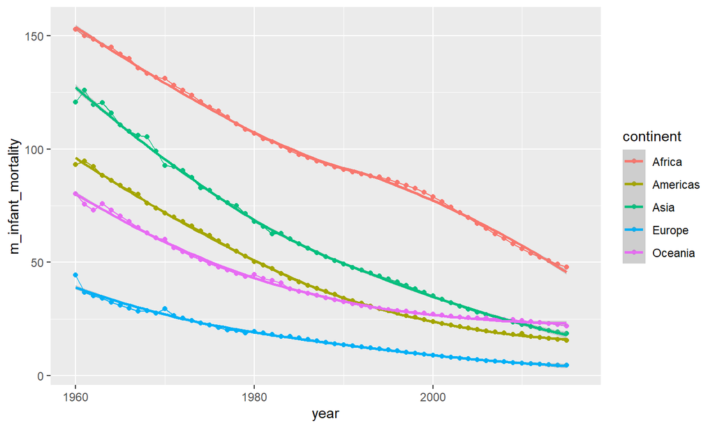

```r
library(dslabs)
gapminder %>% group_by(year, continent) %>%
  summarize(m_infant_mortality = mean(infant_mortality, na.rm = TRUE)) %>%
  ggplot(aes(x = year, y = m_infant_mortality, color = continent)) +
    geom_line() +
    geom_point() +
    geom_smooth()
```

## Distributions of multiple datapoints in categories

When you have multiple values ordered in a categorical variable. Simple plots become messy:

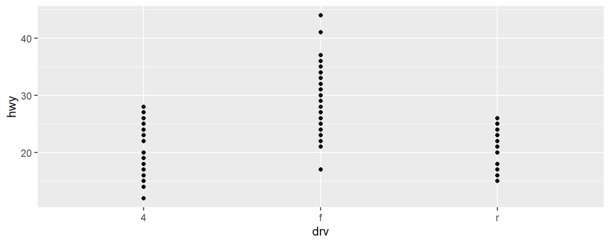

```r
ggplot(mpg,aes(drv, hwy)) +
  geom_point()
```

## Distributions of multiple datapoints in categories (2)

Solutions

- `geom_jitter()` : Adds a litle random jitter to each datapoint
- `geom_boxplot()` : Draws a boxplot
- `geom_violin()` : Draws a violine plot

## Task

- Take the `mgp` dataset
- Create the following plots for the variables x = drv and y = hwy
  - geom_jitter()
  - geom_boxplot()
  - geom_violin()

**Please stop the video here! Continue after completing the task!**

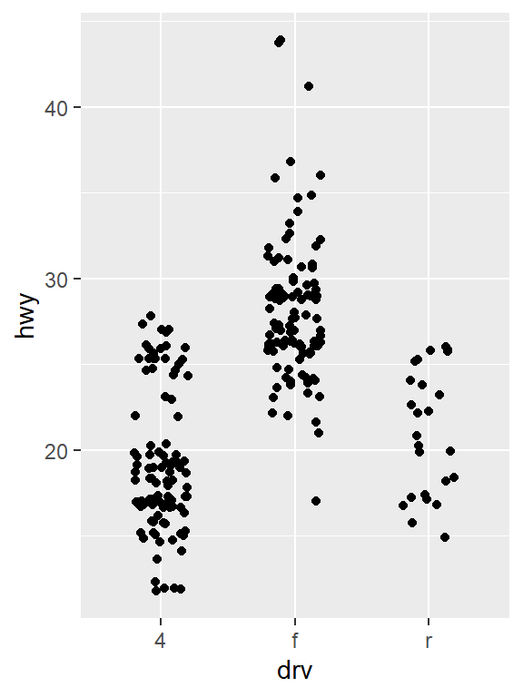

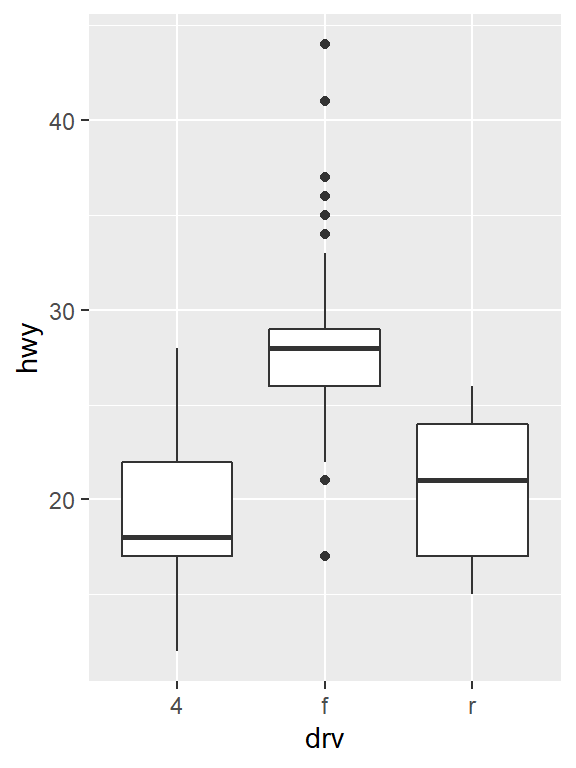

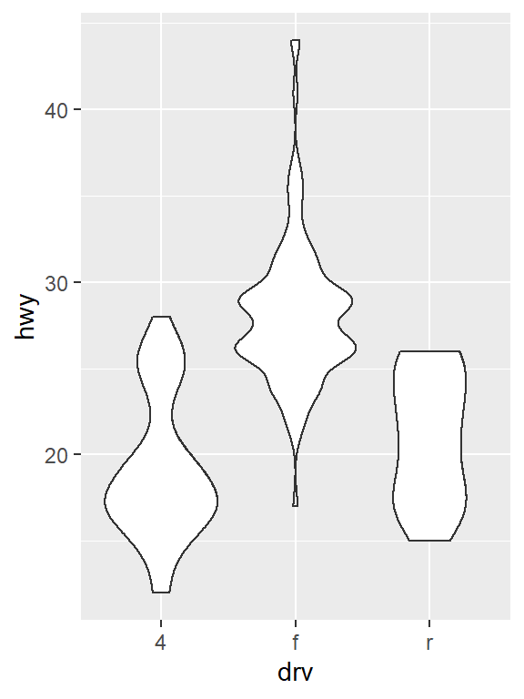

```r
ggplot(mpg,aes(drv, hwy)) +geom_jitter(width = 0.2)
ggplot(mpg,aes(drv, hwy)) +geom_boxplot()
ggplot(mpg,aes(drv, hwy)) +geom_violin()
```

## Further layers

- Add a title: ggtitle() ( e.g. ggtitle(“My first plot”) )
- Change axis labels: labs(x = NULL, y = NULL) (e.g. labs(x = “Categories”, y = “Mean”))
- Change axis scales: ylim(min = 0, max = 10) ; xlim(min = 0, max = 10)

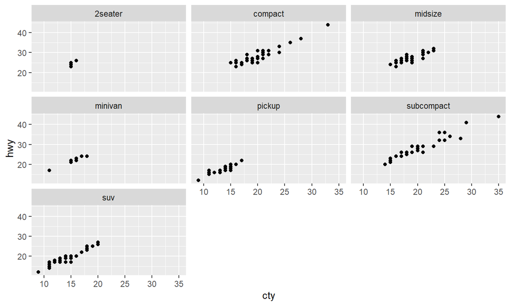

```r
ggplot(mpg, aes(cty, hwy)) +
  geom_point() +
  facet_wrap(~class)
```

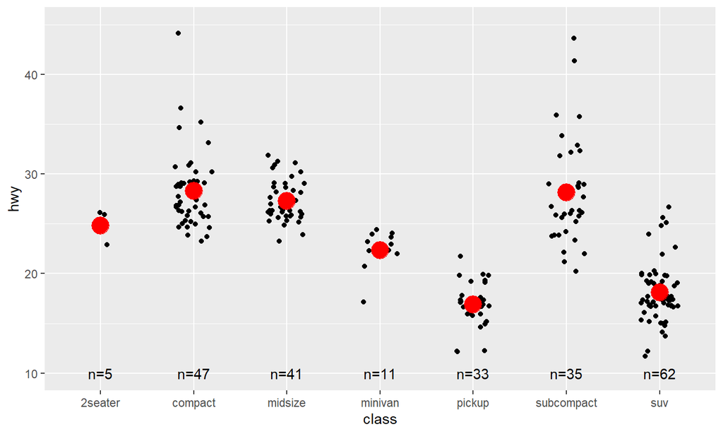

```r
class <- mpg %>%
  group_by(class) %>%
  summarise(n=n(), hwy = mean(hwy))

ggplot(mpg, aes(class, hwy)) +
  geom_jitter(width = 0.2) +
  geom_point(data = class, mapping = aes(class, hwy), colour = "red", size = 6) +
  geom_text(data = class, aes(class, 10, label = paste0("n=", n))) +
  ylim(10, 45)
```